# Figures

Felix Wu

2026-01-21

Rmarkdown notebook for plotting the repeat figures (Figure 3 in draft manuscript)

## Load packages, data

Load packages

```r
source("../utils/genome_plots.R")

req_pkgs <- c("data.table", "stringr", "ggpubr", "patchwork")
LoadPackages(req_pkgs)

SetBaseTheme(base_family="Arial", fontpath="../utils/fonts")
```

Load repeat data. This is genome assembly repeat abundances.

```r
rpt_dat <- fread("tables/REPEAT_SUMMARY.tab", header=TRUE, sep="\t")
rpt_dat <- dcast(rpt_dat, repID + repFamily + repOrder + repSuperfamily + repClade ~ spp, value.var=c("indRepCount", "indRepBP"))
old_nms <- str_subset(names(rpt_dat), "_roe$") # Fix shortened roemeriana name
setnames(rpt_dat, old_nms, str_c(old_nms, "m"))
```

Load TE-SV data. This includes counts across all SVs in a category and subsamplings of SVs in the *Phlox sp.*-present category, which are required for bootstrap p-value calculation.

```r
nsubsamp <- 500 # This many subsamples were taken

tesv_dat <- NULL
for(nm in c("1sp", "2sp", "3sp", "pres")){
    tmp <- fread(str_interp("te_sv_counts/te_sv_counts.${nm}.tsv"), header=TRUE)
    if(is.null(tesv_dat)){
        tesv_dat <- tmp
    } else {
        tesv_dat <- merge(tesv_dat, tmp, by="repID")
    }
}

# Phlox sp.-present subsamples
for(i in 1:nsubsamp){
    tmp <- fread(str_interp("te_sv_counts/presSubsamp/te_sv_counts.presSubsamp.${i}.tsv"),
                 header=TRUE)
    old_nms <- str_subset(names(tmp), "repID", negate=TRUE)
    new_nms <- str_c(old_nms, "N", i)
    setnames(tmp, old_nms, new_nms)
    tesv_dat <- merge(tesv_dat, tmp, by="repID")
}
rm(tmp); gc()
```

```
##           used (Mb) gc trigger  (Mb) max used (Mb)
## Ncells  967847 51.7    1883974 100.7  1420894 75.9
## Vcells 4350626 33.2   12255594  93.6 12255555 93.6
```

```r
# Filter out simple repeats
tesv_dat <- tesv_dat[!str_detect(repID, "^\\(.*n$")][!str_detect(repID, "-rich$")]

# Merge with repeat data
tesv_dat <- merge(tesv_dat, rpt_dat, by="repID", all.x=TRUE)
for(sp in c("drum", "cusp", "roem")){
    newcol <- str_interp("${sp}Shared")
    newval <- tesv_dat[[str_interp("${sp}Pres")]] - tesv_dat[[str_interp("${sp}Uniq")]]
    tesv_dat[, eval(newcol) := newval]
}
```

Create list objects to hold plots and regression data for later joint plotting w/ patchwork

```r
plist <- list()
mlist <- list()
```

## TE-SV comparisons

These are comparisons include: * TE-SV counts vs TE-SV counts. E.g., counts for SVs found in all species vs just one species. * Overall genomic abundance vs TE-SV counts

First load comparisons

```r
comp_tab <- fread("te_sv_comparisons.tsv", header=TRUE, sep="\t")
comp_tab[, NAME := str_c(YVAR, "::", XVAR)]
setkey(comp_tab, NAME)
print(comp_tab)
```

```
## Key: <NAME>
##         XVAR             YVAR
##       <char>           <char>
##  1: cuspUniq         cuspPres
##  2: drumPres         cuspPres
##  3: roemPres         cuspPres
##  4: drumUniq         cuspUniq
##  5: roemUniq         cuspUniq
##  6: drumUniq         drumPres
##  7: cuspPres indRepCount_cusp
##  8: drumPres indRepCount_drum
##  9: roemPres indRepCount_roem
## 10: drumPres         roemPres
## 11: roemUniq         roemPres
## 12: drumUniq         roemUniq
```

[output cut: 42 more lines]

### Regression

Compute GLM for each comparison. We’re using Negative Binomial with identity link due to count data and fixing the intercept at 0 (the origin)

```r
for(nm in comp_tab[["NAME"]]){
    xvar <- comp_tab[nm, XVAR]
    yvar <- comp_tab[nm, YVAR]
    # mlist[[nm]] <- RunOLS(tesv_dat, xvar = xvar, yvar = yvar)
    # mlist[[nm]] <- RunPoisson(tesv_dat, xvar = xvar, yvar = yvar,
    #     link = "identity", ols_start = TRUE)
    mlist[[nm]] <- RunNegBinom(tesv_dat, xvar = xvar, yvar = yvar,
          link = "identity", ols_start = TRUE)
}
```

### Plotting

Plot TE-SV counts and GLM results for each comparison.

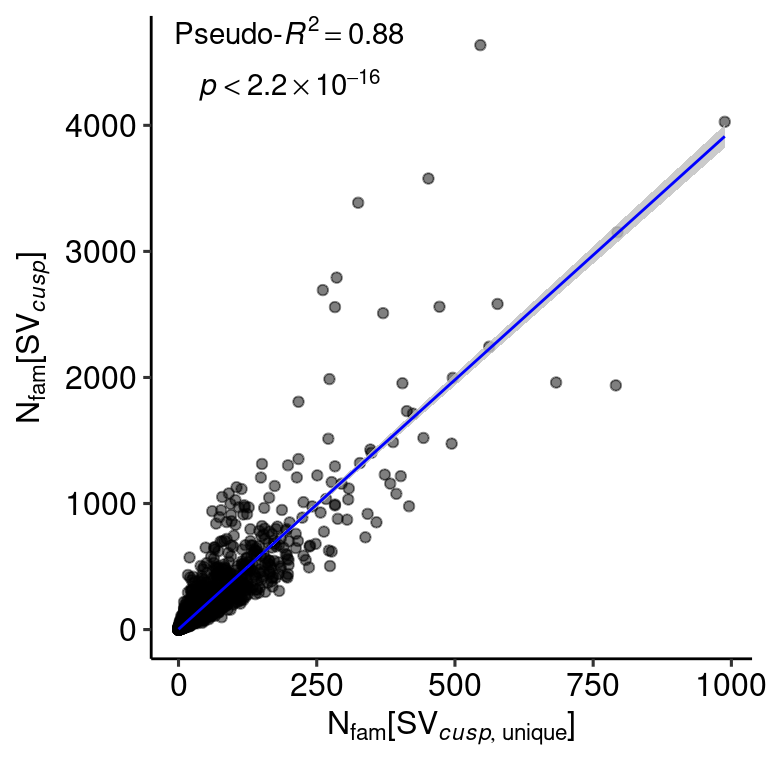

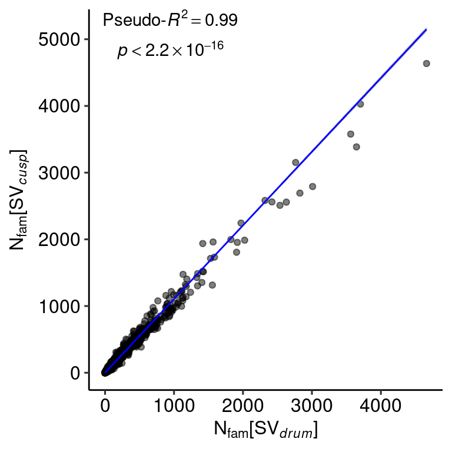

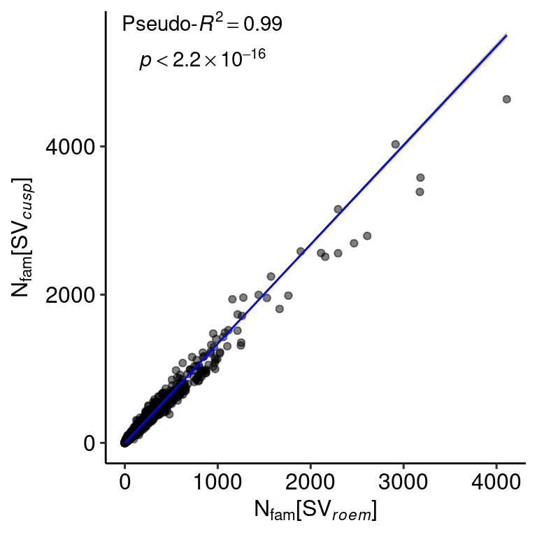

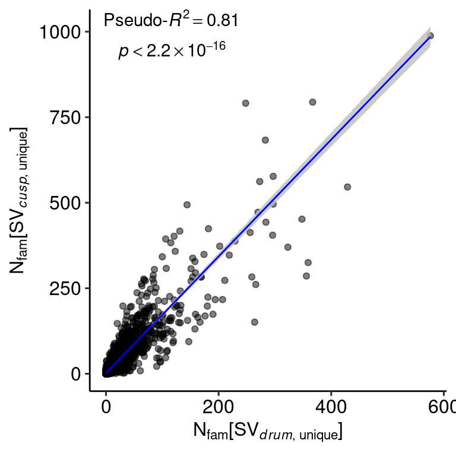

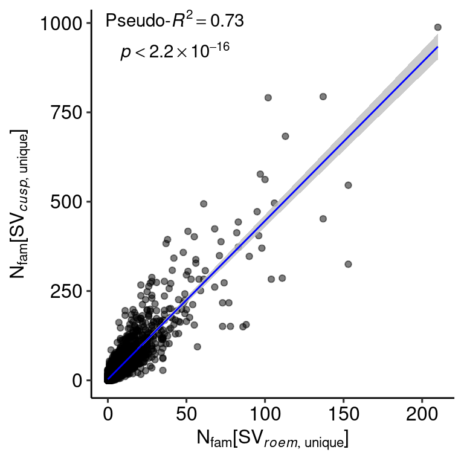

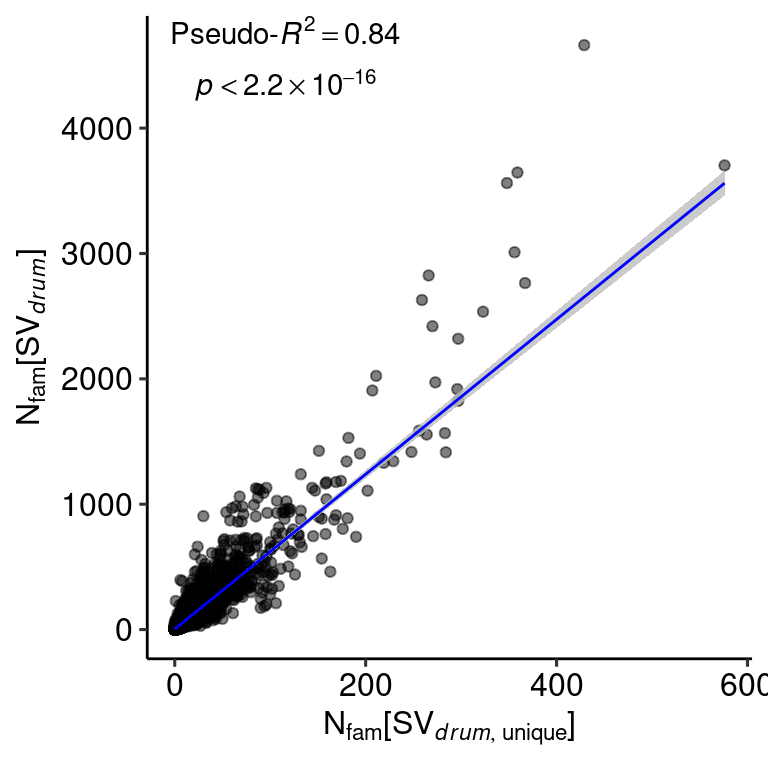

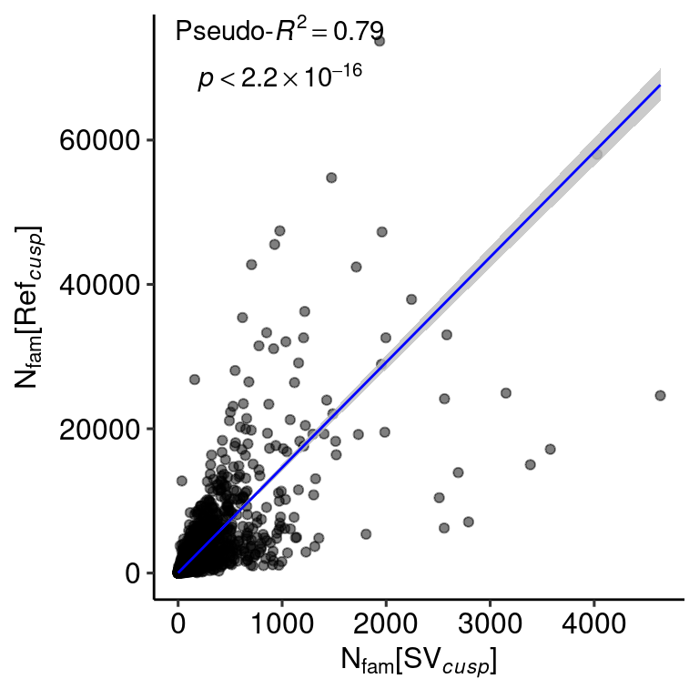

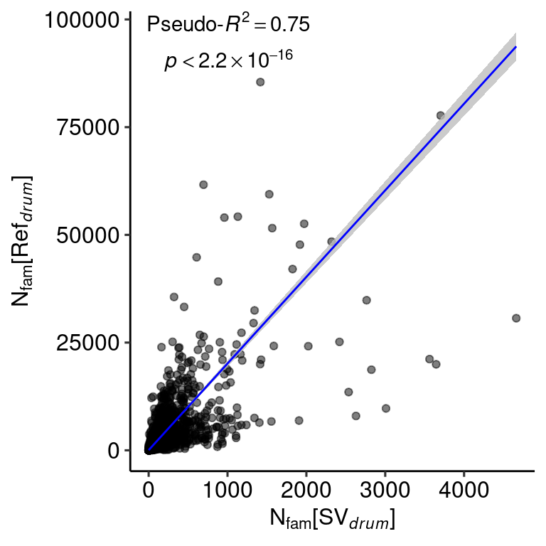

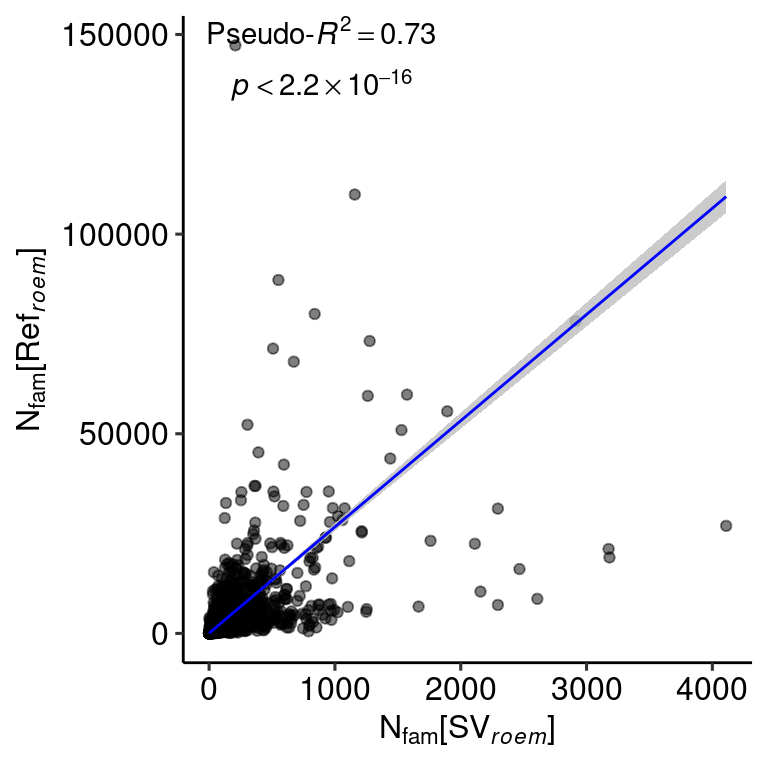

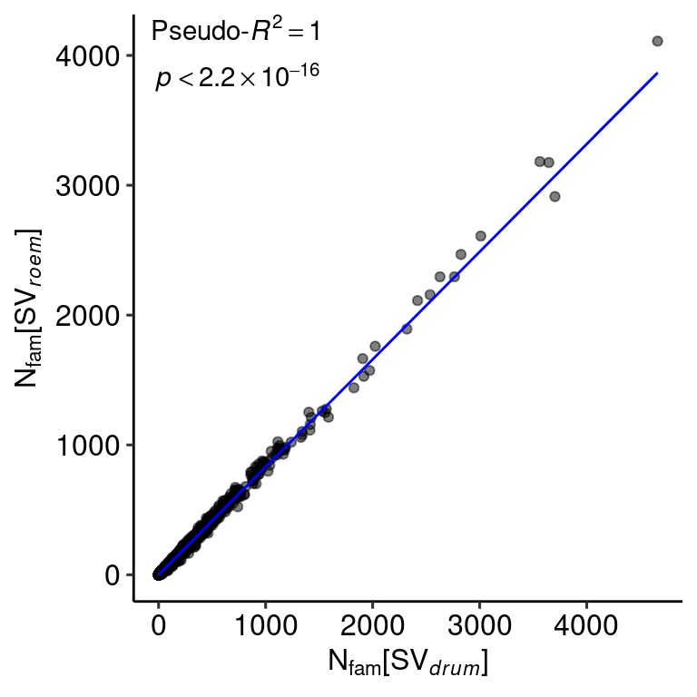

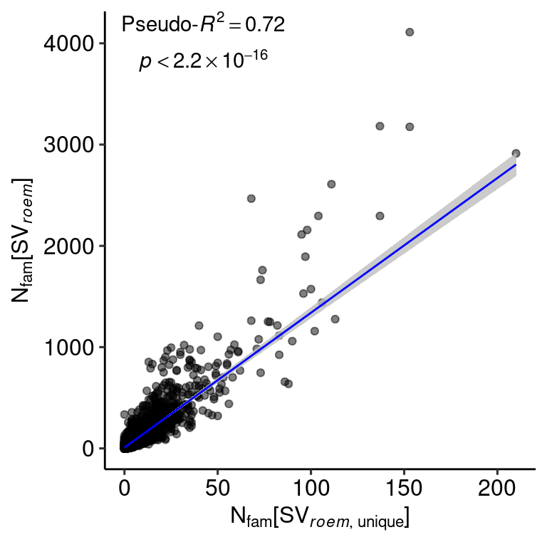

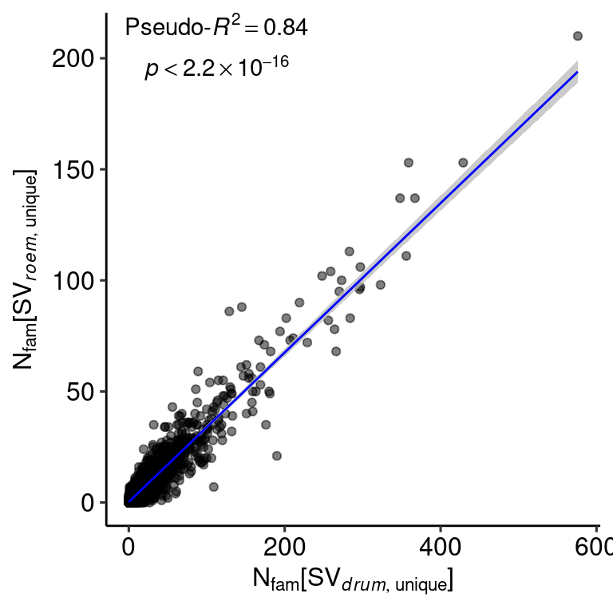

```r
for(nm in comp_tab[["NAME"]]){
    m <- mlist[[nm]]
    labelstr <- FormatR2PvalLab(c(m$rsq, m$pval), stacked=TRUE, pseudo=TRUE)

    xvar <- comp_tab[nm, XVAR]
    yvar <- comp_tab[nm, YVAR]

    xlab_str <- comp_tab[nm, XLAB]
    ylab_str <- comp_tab[nm, YLAB]

    # pts_color <- ifelse(str_starts(yvar, "indRepCount"),
    #                     Load4SpPal()[strsplit(yvar, "_")[[1]][2]],
    #                     "black")
    pts_color <- "black"

    p <- ggplot() +
        geom_point(aes(x=.data[[xvar]], y=.data[[yvar]]), data=tesv_dat, color=pts_color, alpha=0.5) +
        geom_ribbon(aes(x=.data[[xvar]], y=.data[[yvar]], ymin=LWR, ymax=UPR), data=m$fitdat,
            fill="gray", color=NA, alpha=0.8) +
        geom_line(aes(x=.data[[xvar]], y=.data[[yvar]]), data=m$fitdat, color="blue") +
        annotate("text", x=-Inf, y=Inf, hjust=-0.1, vjust=1, label=labelstr, parse=TRUE)

    if(str_starts(xlab_str, "bquote")){
        p <- p + xlab(eval(parse(text=xlab_str)))
    } else {
        p <- p + xlab(xlab_str)
    }

    if(str_starts(ylab_str, "bquote")){
        p <- p + ylab(eval(parse(text=ylab_str)))
    } else {
        p <- p + ylab(ylab_str)
    }

    plist[[nm]] <- p
    print(p)
}
```

## cuspPresSubsamp vs drumPresSubsamp bootstrap

We observe that TE counts for SVs unique to *P. drummondii* explains less variance in TE counts for SVs unique to *P. cuspidata* compared to TE counts for SVs that are merely detected in the two species (i.e., not requiring uniqueness).

To assess the likelihood of this observation, we take a bootstrap approach, subsampling the complement of SVs present in *P. drummondii* and *P. cuspidata* to match number of SVs found to be respectively unique and count TEs as usual. We then compute a distribution of (pseudo-) R^2 values in their correlations and compare them to that observed in the unique vs unique set.

```r
m_bootlist <- list()

for(i in 1:nsubsamp){
    xvar <- str_c("drumPresSubsampN", i)
    yvar <- str_c("cuspPresSubsampN", i)
    m_bootlist[[i]] <- RunNegBinom(tesv_dat, xvar = xvar, yvar = yvar,
                                link = "identity", ols_start = TRUE)
}
```

Plot the pseudo-R^2 distribution along with observed

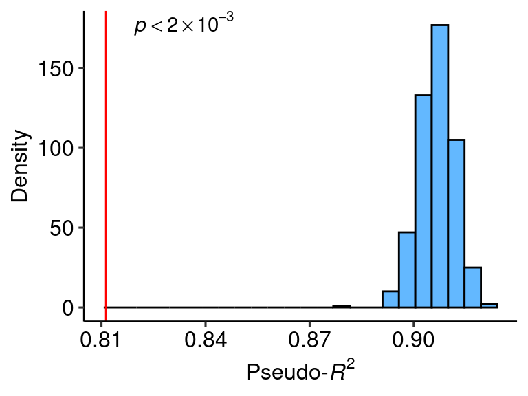

```r
r2_boot <- data.table(
    RSQ = unlist(lapply(m_bootlist, function(x) x$rsq))
)

r2_obs <- mlist[["cuspUniq::drumUniq"]]$rsq
pval <- sum(r2_obs >= r2_boot$RSQ) / nsubsamp
if(pval == 0){
    pval_lab <- str_c("italic(p) < ", FloatAsSci(1 / nsubsamp))
} else {
    pval_lab <- str_c("italic(p) == ", FloatAsSci(pval))
}

p <- ggplot(r2_boot, aes(x=RSQ)) +
    # geom_density(fill="steelblue1") +
    geom_histogram(bins=nclass.FD(r2_boot$RSQ), fill="steelblue1", color="black") +
    geom_vline(aes(xintercept = r2_obs), color="red") +
    annotate("text", x=-Inf, y=Inf, hjust=-0.5, vjust=1, label=pval_lab, parse=TRUE) +
    xlab(bquote("Pseudo-" * italic(R)^2)) +
    ylab("Density")

plist[["boot_hist"]] <- p
print(p)
```

## Joint plot

Use patchwork syntax to display key plots together

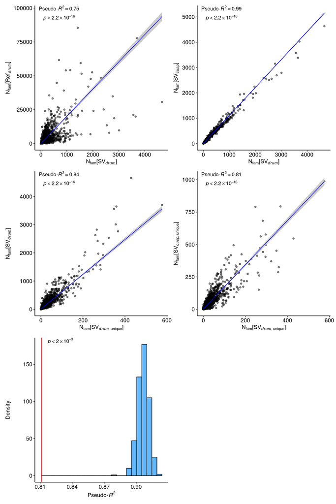

```r
p1 <- plist[["indRepCount_drum::drumPres"]]
p2 <- plist[["cuspPres::drumPres"]]
p3 <- plist[["drumPres::drumUniq"]]
p4 <- plist[["cuspUniq::drumUniq"]]
p5 <- plist[["boot_hist"]]

p <- p1 + p2 + p3 + p4 + p5 +
    plot_layout(ncol=2)
ggsave(p, file="figures.pdf", width=10, height=15)
print(p)
```